# classification Project

Amirali Bagherzade

2023-07-08

# packages

```r
library(tibble)
```

```r
library(ggplot2)
library(rpart)
library(rpart.plot)
library(caret)
library(readr)
library(mlbench)
library(cowplot)
library(nnet)
library(readr)
library(MASS)
library(e1071)
library(pROC)
library(randomForest)
dpd = read_csv("C:/Users/USER/Desktop/diabetes.csv")
dpd$hypertension=factor(dpd$hypertension)
dpd$gender=factor(dpd$gender)
dpd$smoking_history=factor(dpd$smoking_history)
dpd$heart_disease=factor(dpd$heart_disease)
dpd$diabetes=factor(dpd$diabetes)
```

## barplot of diabetic and non-diabetic

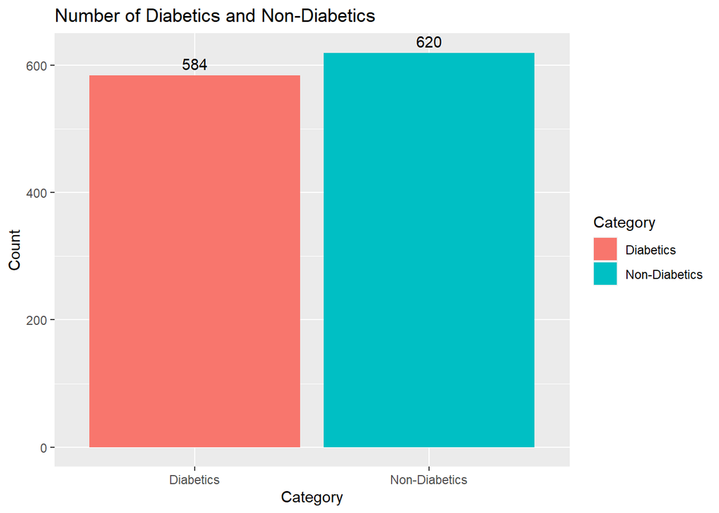

```r
diabetics_count = sum(dpd$diabetes == 1)
non_diabetics_count = sum(dpd$diabetes == 0)


df = data.frame(Category = c("Diabetics", "Non-Diabetics"),
                 Count = c(diabetics_count, non_diabetics_count))


ggplot(df, aes(x = Category, y = Count, fill = Category)) +
  geom_bar(stat = "identity") +
  geom_text(aes(label = Count), vjust = -0.5) +
  labs(title = "Number of Diabetics and Non-Diabetics",
       x = "Category", y = "Count")
```

## barplot of gender

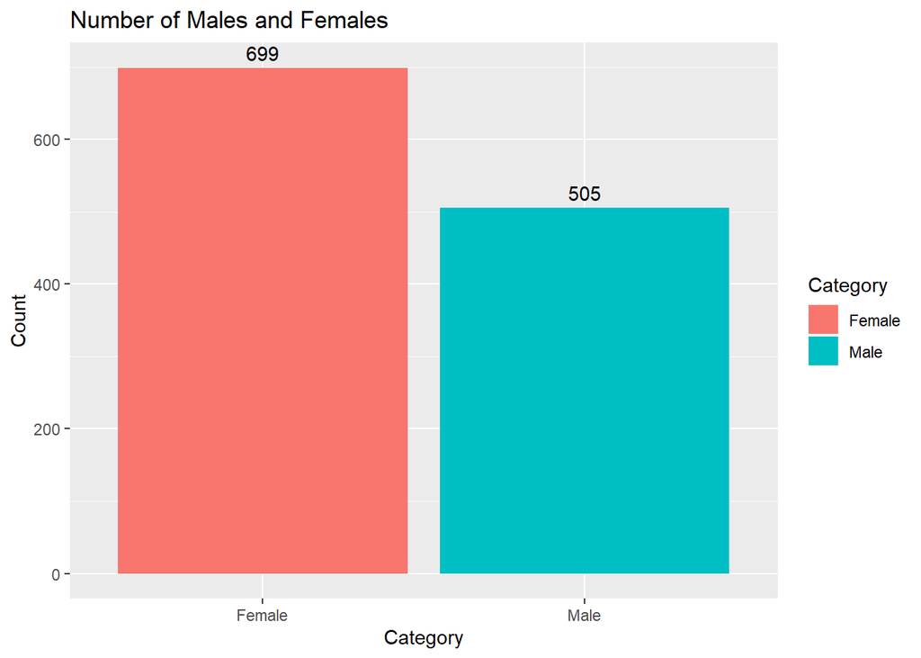

```r
males_count = sum(dpd$gender == "Male")
females_count = sum(dpd$gender == "Female")

df = data.frame(Category = c("Male", "Female"),
                 Count = c(males_count, females_count))

ggplot(df, aes(x = Category, y = Count, fill = Category)) +
  geom_bar(stat = "identity") +
  geom_text(aes(label = Count), vjust = -0.5) +
  labs(title = "Number of Males and Females",
       x = "Category", y = "Count")
```

## histogram of age

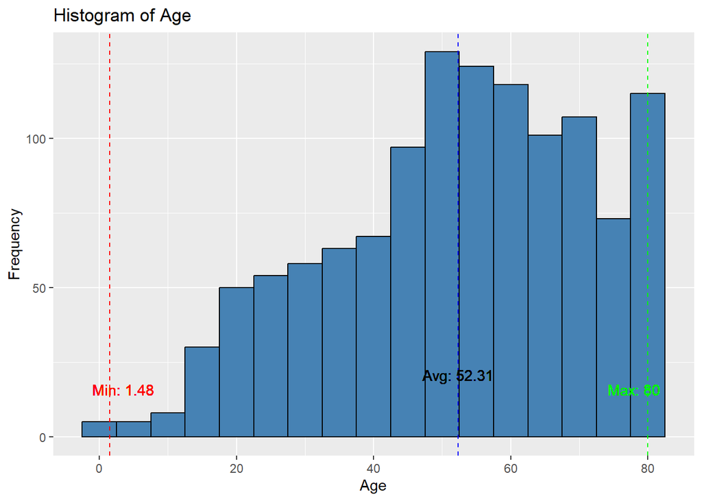

```r
min_age = min(dpd$age)
max_age = max(dpd$age)
avg_age = mean(dpd$age)

# Create the histogram
ggplot(dpd, aes(x = age)) +
  geom_histogram(binwidth = 5, fill = "steelblue", color = "black") +
  geom_vline(xintercept = c(min_age, max_age, avg_age),
             linetype = "dashed", color = c("red", "green", "blue")) +
  geom_text(aes(x = min_age + 2, y = 10, label = paste0("Min: ", min_age)),
            color = "red", vjust = -1) +
  geom_text(aes(x = max_age - 2, y = 10, label = paste0("Max: ", max_age)),
            color = "green", vjust = -1) +
  geom_text(aes(x = avg_age, y = 15, label = paste0("Avg: ", round(avg_age, 2))),
            color = "black", vjust = -1) +
  labs(title = "Histogram of Age",
       x = "Age", y = "Frequency")
```

## histogram of blood glucose level

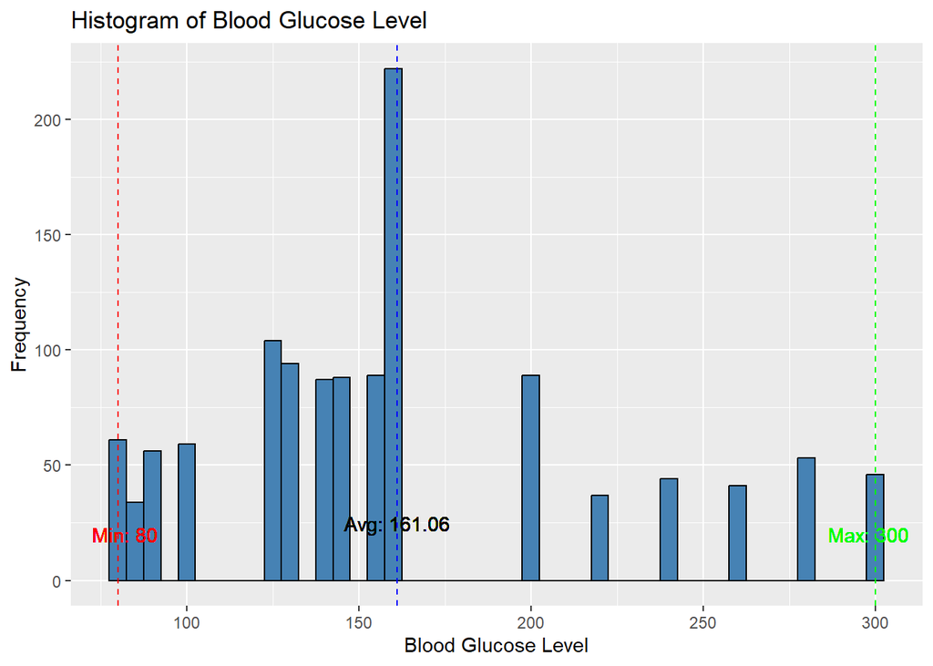

```r
min_glucose = min(dpd$blood_glucose_level)
max_glucose = max(dpd$blood_glucose_level)
avg_glucose = mean(dpd$blood_glucose_level)

# Create the histogram
ggplot(dpd, aes(x = dpd$blood_glucose_level)) +
  geom_histogram(binwidth = 5, fill = "steelblue", color = "black") +
  geom_vline(xintercept = c(min_glucose, max_glucose, avg_glucose),
             linetype = "dashed", color = c("red", "green", "blue")) +
  geom_text(aes(x = min_glucose + 2, y = 10, label = paste0("Min: ", min_glucose)),
            color = "red", vjust = -1) +
  geom_text(aes(x = max_glucose - 2, y = 10, label = paste0("Max: ", max_glucose)),
            color = "green", vjust = -1) +
  geom_text(aes(x = avg_glucose, y = 15, label = paste0("Avg: ", round(avg_glucose, 2))),
            color = "black", vjust = -1) +
  labs(title = "Histogram of Blood Glucose Level",
       x = "Blood Glucose Level", y = "Frequency")
```

## histogram of HbA1c_level

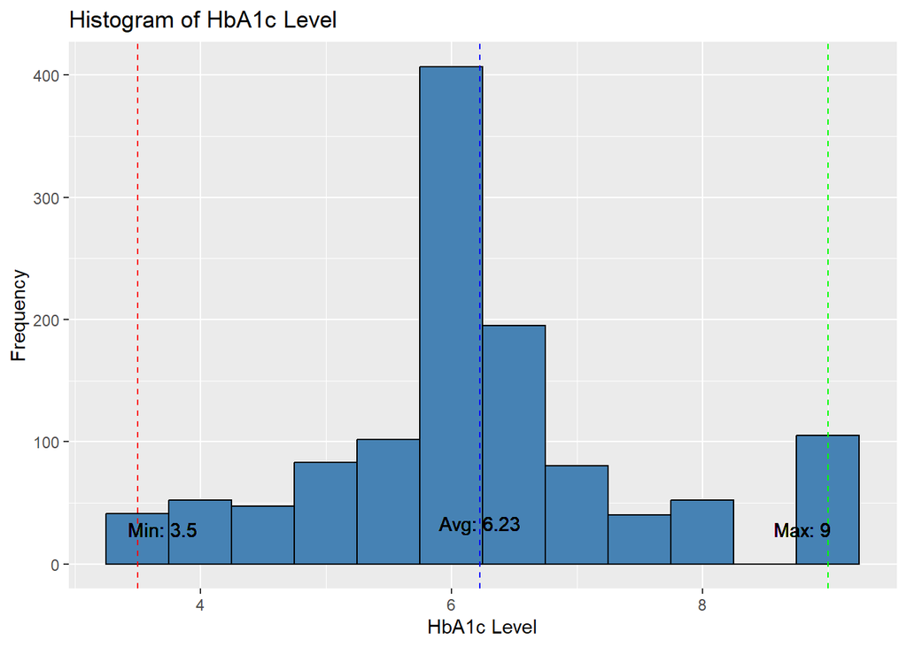

```r
min_HbA1c = min(dpd$HbA1c_level)
max_HbA1c = max(dpd$HbA1c_level)
avg_HbA1c = mean(dpd$HbA1c_level)

# Create the histogram
ggplot(dpd, aes(x = HbA1c_level)) +
  geom_histogram(binwidth = 0.5, fill = "steelblue", color = "black") +
  geom_vline(xintercept = c(min_HbA1c, max_HbA1c, avg_HbA1c),
             linetype = "dashed", color = c("red", "green", "blue")) +
  geom_text(aes(x = min_HbA1c + 0.2, y = 10, label = paste0("Min: ", min_HbA1c)),
            color = "black", vjust = -1) +
  geom_text(aes(x = max_HbA1c - 0.2, y = 10, label = paste0("Max: ", max_HbA1c)),
            color = "black", vjust = -1) +
  geom_text(aes(x = avg_HbA1c, y = 15, label = paste0("Avg: ", round(avg_HbA1c, 2))),
            color = "black", vjust = -1) +
  labs(title = "Histogram of HbA1c Level",
       x = "HbA1c Level", y = "Frequency")
```

## Train and test

```r
set.seed(100)
# tst-trn split data
dpd_trn_idx = sample(nrow(dpd), size = 0.8 * nrow(dpd))
dpd_trn = dpd[dpd_trn_idx, ]
dpd_tst = dpd[-dpd_trn_idx, ]

# est-val split data
dpd_est_idx = sample(nrow(dpd_trn), size = 0.8 * nrow(dpd_trn))
dpd_est = dpd_trn[dpd_est_idx, ]
dpd_val = dpd_trn[-dpd_est_idx, ]

head(dpd_trn)
```

```
## # A tibble: 6 × 9
##   gender   age hypertension heart_disease smokin…¹   bmi HbA1c…² blood…³ diabe…⁴
##   <fct>  <dbl> <fct>        <fct>         <fct>    <dbl>   <dbl>   <dbl> <fct>
## 1 Female    37 0            0             yes       24.7     6       158 0
## 2 Male      63 1            0             yes       25.2     8.2     155 1
## 3 Female    80 0            0             never     25.0     9       145 1
## 4 Female    54 0            0             never     31.9     9       159 1
## 5 Female    72 0            0             yes       27.3     3.5     160 0
## 6 Female    80 1            0             yes       31.1     6.1     260 1
## # … with abbreviated variable names ¹smoking_history, ²HbA1c_level,
## #   ³blood_glucose_level, ⁴diabetes
```

# EDA

```r
table(dpd_est$gender)
```

```
##
## Female   Male
##    439    331
```

```r
table(dpd_est$heart_disease)
```

```
##
##   0   1
## 696  74
```

```r
table(dpd_est$smoking_history)
```

```
##
## never   yes
##   373   397
```

```r
table(dpd_est$diabetes)
```

```
##
##   0   1
## 398 372
```

# scatter plots

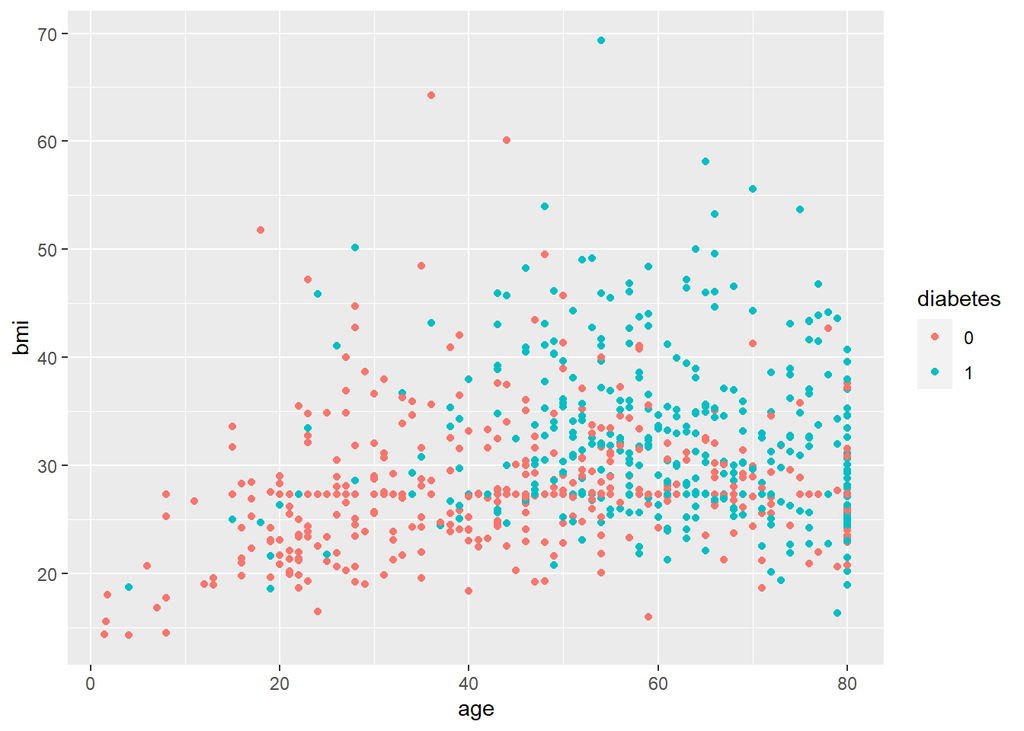

```r
ggplot(
  data=dpd_est,
  aes(x = age,y = bmi,group = diabetes,colour = diabetes))+
    geom_point()
```

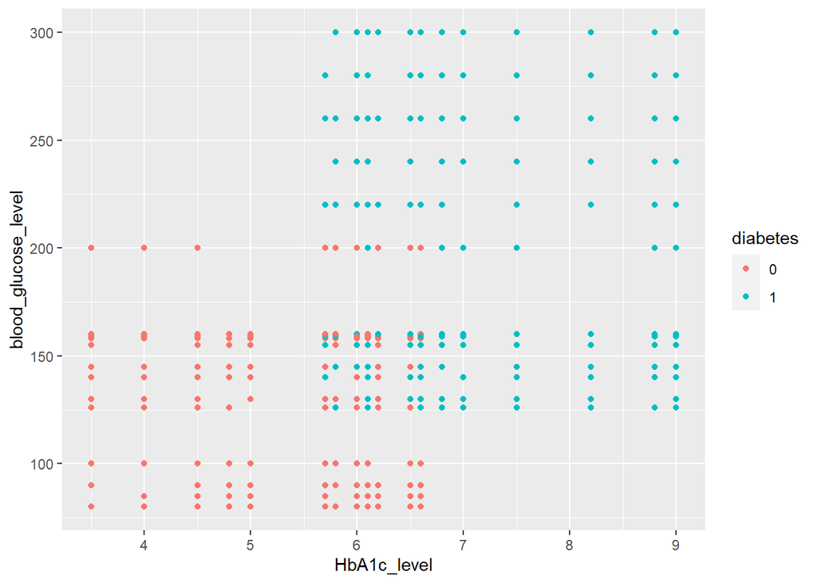

```r
ggplot(
  data=dpd_est,
  aes(x = HbA1c_level,y = blood_glucose_level,group = diabetes,colour = diabetes))+
    geom_point()
```

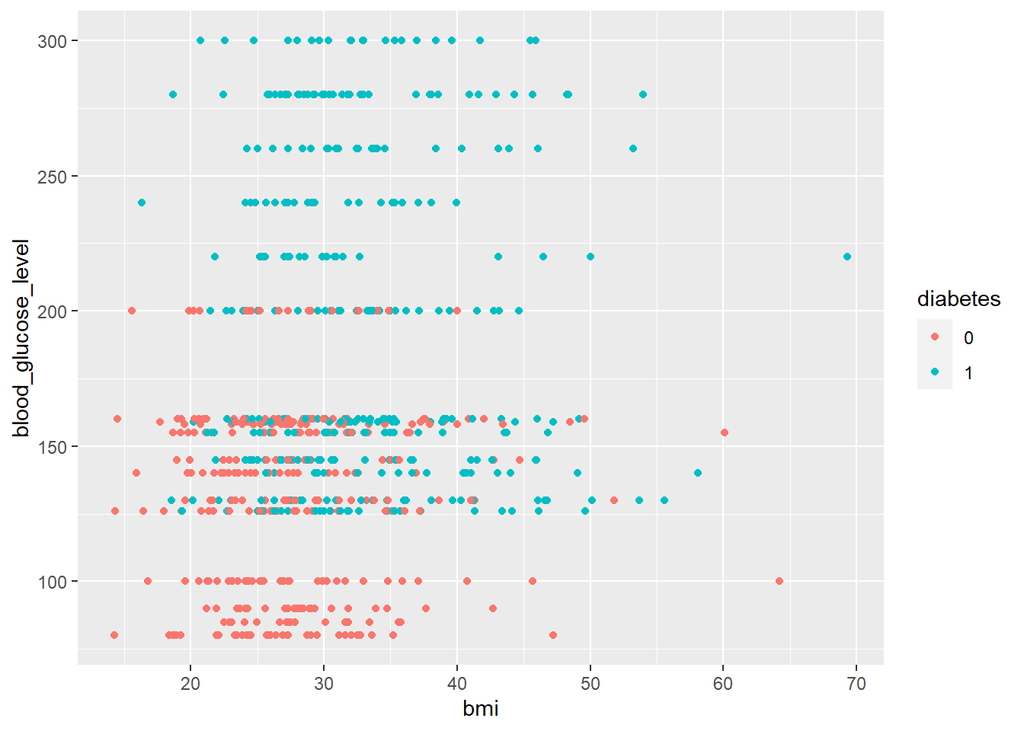

```r
ggplot(
  data=dpd_est,
  aes(x = bmi,y = blood_glucose_level,group = diabetes,colour = diabetes))+
    geom_point()
```

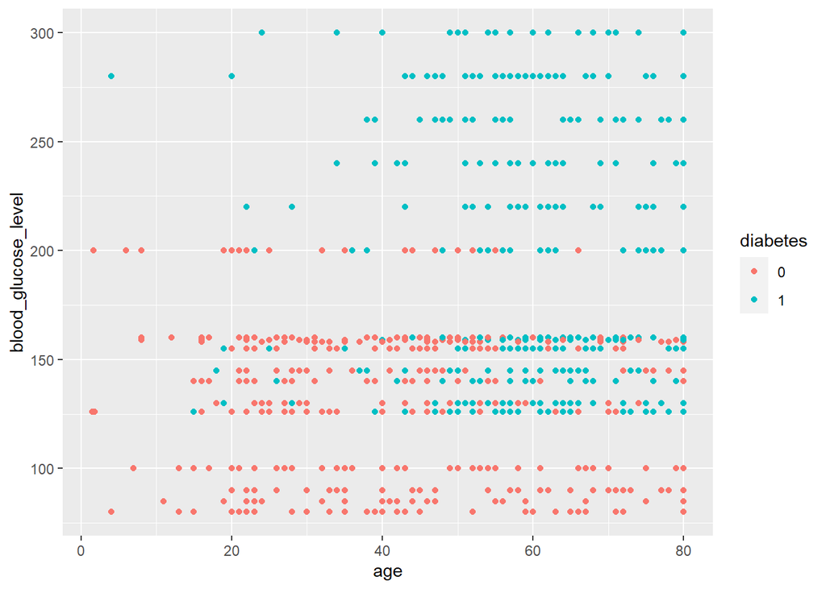

```r
ggplot(
  data=dpd_est,
  aes(x = age,y = blood_glucose_level,group = diabetes,colour = diabetes))+
    geom_point()
```

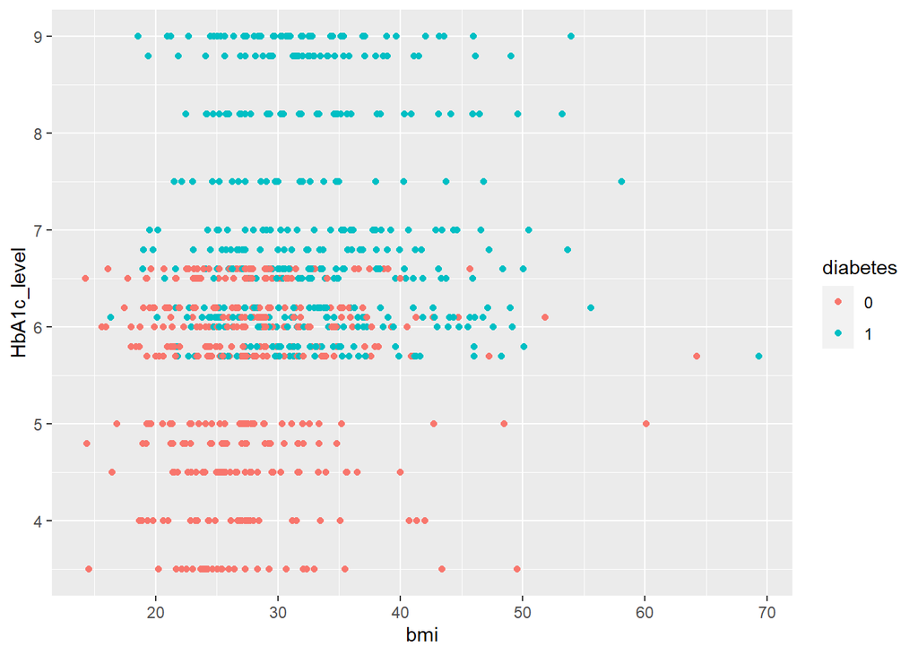

```r
ggplot(
  data=dpd_trn,
  aes(x = bmi,y =HbA1c_level,group = diabetes,colour = diabetes))+
    geom_point()
```

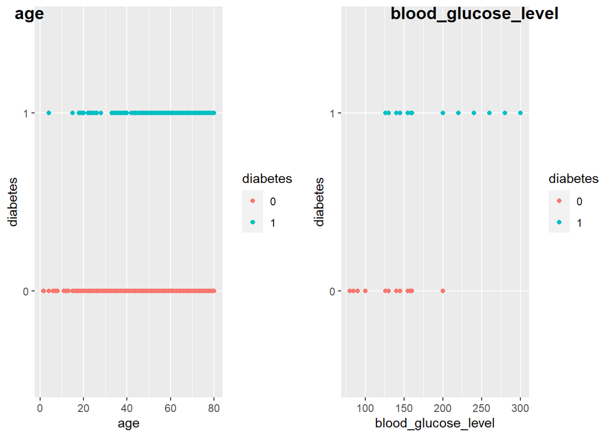

```r
plot1=ggplot(
  data=dpd_est,
  aes(x=age,y=diabetes,group=diabetes, colour=diabetes))+
  geom_point()
plot2=ggplot(
  data=dpd_est,
  aes(x=blood_glucose_level,y=diabetes,group=diabetes, colour=diabetes))+
  geom_point()
plot_grid(plot1,plot2, labels=c('age','blood_glucose_level'))
```

# Models

## calc_missclass

```r
calc_misclass = function(actual, predicted) {
  mean(actual != predicted)
}
```

## KNN

```r
dpd_est_scaled = dpd_est

dpd_est_scaled$age = scale(dpd_est_scaled$age)
age.center = attr(dpd_est_scaled$age,"scaled:center")
age.scale = attr(dpd_est_scaled$age,"scaled:scale")

dpd_est_scaled$bmi = scale(dpd_est_scaled$bmi)
bmi.center = attr(dpd_est_scaled$bmi,"scaled:center")
bmi.scale = attr(dpd_est_scaled$bmi,"scaled:scale")

dpd_est_scaled$HbA1c_level = scale(dpd_est_scaled$HbA1c_level)
HbA1c_level.center = attr(dpd_est_scaled$HbA1c_level,"scaled:center")
HbA1c_level.scale = attr(dpd_est_scaled$HbA1c_level,"scaled:scale")

dpd_est_scaled$blood_glucose_level = scale(dpd_est_scaled$blood_glucose_level)
blood_glucose_level.center = attr(dpd_est_scaled$blood_glucose_level,"scaled:center")
blood_glucose_level.scale = attr(dpd_est_scaled$blood_glucose_level,"scaled:scale")
```

### Validation

```r
dpd_val_scaled = dpd_val

dpd_val_scaled$age = scale(dpd_val_scaled$age, center = age.center, scale = age.scale)
dpd_val_scaled$bmi = scale(dpd_val_scaled$bmi, center = bmi.center, scale = bmi.scale)
dpd_val_scaled$HbA1c_level = scale(dpd_val_scaled$HbA1c_level, center = HbA1c_level.center, scale = HbA1c_level.scale)
dpd_val_scaled$blood_glucose_level = scale(dpd_val_scaled$blood_glucose_level, center = blood_glucose_level.center, scale = blood_glucose_level.scale)
```

```r
fit_knn_to_est = function(k, data) {
  knn3(diabetes ~ ., data = data, k = k)
}

# k-values
k_val = seq(1, 101, by = 2)
# KNN for k 1:100
scaled_knn_mods = lapply(k_val, fit_knn_to_est, data = dpd_est_scaled)
non_scaled_knn_mods = lapply(k_val, fit_knn_to_est, data = dpd_est)
```

### KNN prediction

```r
# make predictions
non_scaled_knn_preds = lapply(non_scaled_knn_mods, predict, dpd_val, type = "class")
scaled_knn_preds = lapply(scaled_knn_mods, predict, dpd_val_scaled, type = "class")
```

### calculate misclass

```r
non_scaled_knn_misclass = sapply(non_scaled_knn_preds, calc_misclass, actual = dpd_val$diabetes)
scaled_knn_misclass = sapply(scaled_knn_preds, calc_misclass, actual = dpd_val_scaled$diabetes)
```

### KNN report

```r
knn_misclass_data = data.frame(col1 = k_val, col2 = non_scaled_knn_misclass, col3 = scaled_knn_misclass)
colnames(knn_misclass_data) = c("K", "non_scaled_missclass", "scaled_missclass")
print(knn_misclass_data)
```

```
##      K non_scaled_missclass scaled_missclass
## 1    1            0.1761658       0.16062176
## 2    3            0.1709845       0.16062176
## 3    5            0.1606218       0.15544041
## 4    7            0.1709845       0.11917098
## 5    9            0.1761658       0.13471503
## 6   11            0.1502591       0.09326425
## 7   13            0.1606218       0.10880829
## 8   15            0.1658031       0.11398964
## 9   17            0.1554404       0.11398964
## 10  19            0.1709845       0.10880829
## 11  21            0.1813472       0.09844560
## 12  23            0.1865285       0.09844560
## 13  25            0.1813472       0.10362694
## 14  27            0.1761658       0.11398964
```

[output cut: 37 more lines]

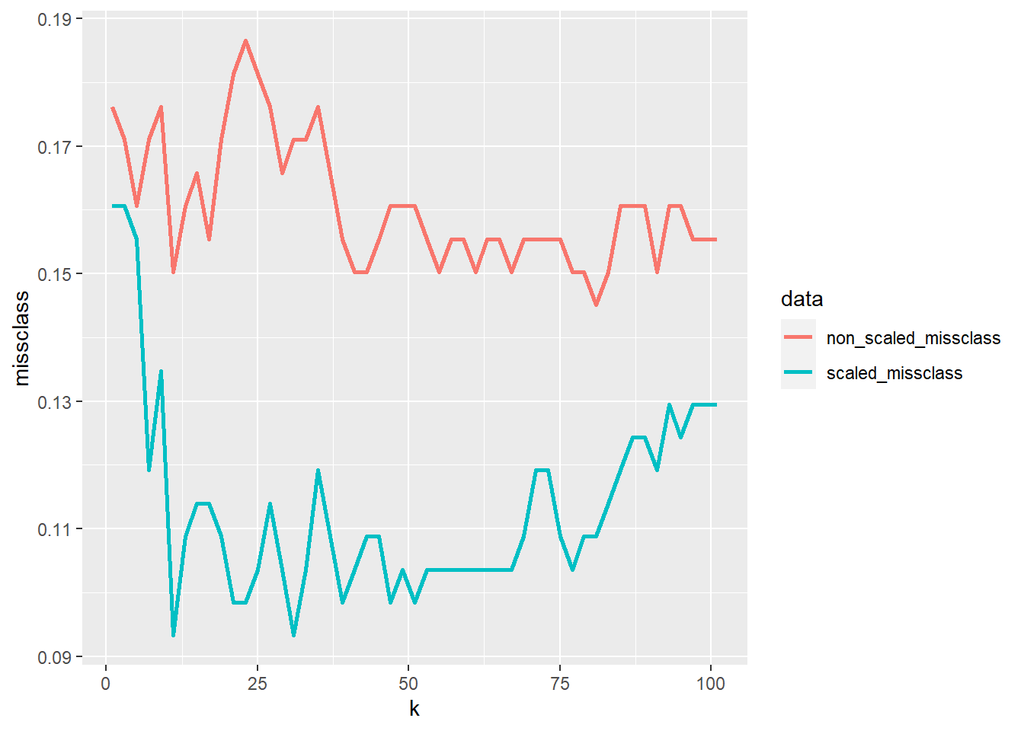

```r
ggplot(knn_misclass_data, aes(x = K)) +
  geom_line(aes(y = non_scaled_missclass,color ='non_scaled_missclass'),linewidth = 1) +
  geom_line(aes(y = scaled_missclass, color = 'scaled_missclass'),linewidth = 1)+
  labs(x = 'k', y = 'missclass', color = 'data')
```

### Best-k

```r
best_k = k_val[which.min(scaled_knn_misclass)]
best_knn_mod = knn3(diabetes ~ ., data = dpd_est_scaled, k = best_k)
knn_mis_est = calc_misclass(dpd_est_scaled$diabetes, predict(best_knn_mod,dpd_est_scaled,type = 'class'))
knn_mis_val = calc_misclass(dpd_val_scaled$diabetes, predict(best_knn_mod,dpd_val_scaled,type = 'class'))

cat("best k is:",best_k,"and the missclassification for estimation is:",knn_mis_est,"and the missclassification for validation is:",knn_mis_val )
```

```
## best k is: 11 and the missclassification for estimation is: 0.112987 and the missclassification for validation is: 0.09326425
```

### Actual vs Predicted

```r
table(predicted = predict(best_knn_mod,dpd_val_scaled,type = 'class'), actual = dpd_val_scaled$diabetes)
```

```
##          actual
## predicted  0  1
##         0 97 13
##         1  5 78
```

## Report

```r
model_selection_df = data.frame("Model" = "Best-KNN",
                                "EST_missclass" = knn_mis_est,
                                "VAL_missclass" = knn_mis_val,
                                row.names = 1)

model_selection_df
```

```
##      Model EST_missclass VAL_missclass
## 1 Best-KNN      0.112987    0.09326425
```

## Decision tree

### tree function

```r
fit_tree_to_est = function(cp ,minsplit){
  rpart(diabetes ~ ., data = dpd_est, cp = cp, minsplit = minsplit)
}
```

```r
cp = c(0.001, 0.01, 0.1, 1)
minsplit = seq(5,30,5)
tree_cp_0.001 = lapply(minsplit, fit_tree_to_est, cp = 0.001)
tree_cp_0.01 = lapply(minsplit, fit_tree_to_est, cp = 0.01)
tree_cp_0.1 = lapply(minsplit, fit_tree_to_est, cp = 0.1)
tree_cp_1 = lapply(minsplit, fit_tree_to_est, cp = 1)
```

```r
tree_cp_0.001_pred = lapply(tree_cp_0.001, predict, dpd_val, type = "class")
tree_cp_0.001_miss = sapply(tree_cp_0.001_pred, calc_misclass, actual = dpd_val$diabetes)

tree_cp_0.01_pred = lapply(tree_cp_0.01, predict, dpd_val, type = "class")
tree_cp_0.01_miss = sapply(tree_cp_0.01_pred, calc_misclass, actual = dpd_val$diabetes)

tree_cp_0.1_pred = lapply(tree_cp_0.1, predict, dpd_val, type = "class")
tree_cp_0.1_miss = sapply(tree_cp_0.1_pred, calc_misclass, actual = dpd_val$diabetes)

tree_cp_1_pred = lapply(tree_cp_1, predict, dpd_val, type = "class")
tree_cp_1_miss = sapply(tree_cp_1_pred, calc_misclass, actual = dpd_val$diabetes)
```

### Tree report

```r
min_tree_cp_0.001_miss = min(tree_cp_0.001_miss)
min_tree_cp_0.01_miss = min(tree_cp_0.01_miss)
min_tree_cp_0.1_miss = min(tree_cp_0.1_miss)
min_tree_cp_1_miss = min(tree_cp_1_miss)

cp_0.001_minsplit = minsplit[which.min(tree_cp_0.001_miss)]
cp_0.01_minsplit = minsplit[which.min(tree_cp_0.01_miss)]
cp_0.1_minsplit = minsplit[which.min(tree_cp_0.1_miss)]
cp_1_minsplit = minsplit[which.min(tree_cp_1_miss)]

tree_miss_class_df = data.frame(c(min_tree_cp_0.001_miss,min_tree_cp_0.01_miss,min_tree_cp_0.1_miss,min_tree_cp_1_miss),
c(0.001,0.01,0.1,1),                        c(cp_0.001_minsplit,cp_0.01_minsplit,cp_0.1_minsplit,cp_1_minsplit))

names(tree_miss_class_df) = c("misscalsification", "CP", "minsplit")
tree_miss_class_df
```

```
##   misscalsification    CP minsplit
## 1         0.1191710 0.001       15
## 2         0.1295337 0.010        5
## 3         0.1813472 0.100        5
## 4         0.4715026 1.000        5
```

```r
best_tree_miss_class = min(tree_miss_class_df[,1])

best_cp = tree_miss_class_df$CP[tree_miss_class_df$misscalsification == min(tree_miss_class_df[,1])]

best_minsplit = tree_miss_class_df$minsplit[tree_miss_class_df$misscalsification == min(tree_miss_class_df[,1])]


cat("best tree miss calsification is:", best_tree_miss_class,"and best CP:",best_cp,"and best minsplit is:",best_minsplit)
```

```
## best tree miss calsification is: 0.119171 and best CP: 0.001 and best minsplit is: 15
```

```r
best_tree = rpart(diabetes ~ ., data = dpd_est, cp = best_cp, minsplit = best_minsplit)
tree_est_mis = calc_misclass(predict(best_tree, dpd_est, type = 'class'), dpd_est$diabetes)
tree_val_mis = calc_misclass(predict(best_tree, dpd_val,type = 'class'), dpd_val$diabetes)
```

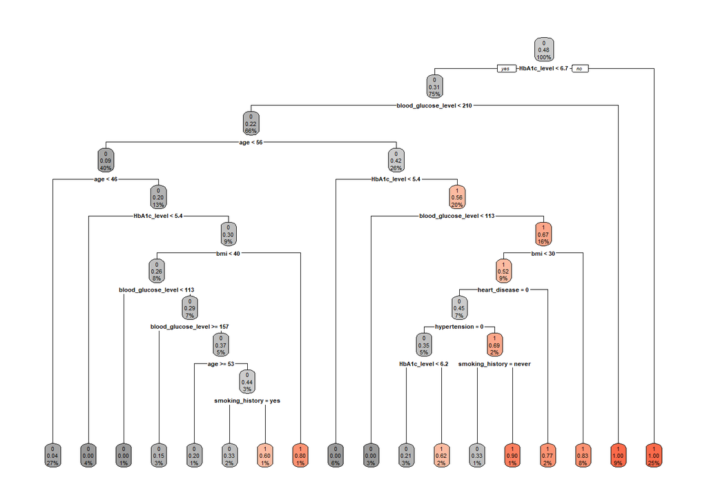

```r
rpart.plot(best_tree, type = 2, box.palette = list("Grays", "Reds"))
```

### Variable importance

```r
best_tree$variable.importance
```

```
##         HbA1c_level blood_glucose_level                 age                 bmi
##         168.6892551         100.2081353          32.0819932          10.9905505
##        hypertension       heart_disease     smoking_history              gender
##           6.9859602           6.3610529           3.2616667           0.1913939
```

### Actual vs Predicted

```r
table(predicted = predict(best_tree, dpd_val,type = 'class'), actual = dpd_val$diabetes)
```

```
##          actual
## predicted  0  1
##         0 89 10
##         1 13 81
```

```r
model_selection_df = rbind(model_selection_df,c("Model" = "Tree",
                            "EST_miscalss" = tree_est_mis,
                                "VAL_misclas" = tree_val_mis))

model_selection_df
```

```
##      Model      EST_missclass      VAL_missclass
## 1 Best-KNN  0.112987012987013 0.0932642487046632
## 2     Tree 0.0636363636363636  0.119170984455959
```

## Random Forest

Random forest is a powerful machine learning algorithm that combines the predictions of multiple decision trees to make more accurate predictions or perform classification tasks. It is considered an ensemble learning method because it aggregates the results of multiple models to improve overall performance.

we use it to show the importance of variables and the accuracy of this algorithm and do not use as a final model.

```r
# mtry = The number of predictor variables randomly sampled as candidates at each split(sqrt(p) for classification)
# ntree = The number of trees to grow in the random forest.
# importance = A logical value indicating whether variable importance measures should be computed.
# nodesize = The minimum size of terminal nodes.
set.seed(150)
forest = randomForest(diabetes ~ ., data = dpd_est, mtry = 3, ntree = 200,
                     nodesize = 5, importance = TRUE)
importance(forest)
```

```
##                             0          1 MeanDecreaseAccuracy MeanDecreaseGini
## gender               2.784091  0.8531057             2.763051         2.783311
## age                 15.226822 15.4238538            21.322335        57.898959
## hypertension         2.811019  1.4379349             2.939849         5.473475
## heart_disease       14.522999  2.1596877            13.673471         8.365638
## smoking_history     -2.195407 -0.5498354            -1.855344         2.816248
## bmi                  7.853788  2.5924698             7.183742        34.494403
## HbA1c_level         55.612050 44.1033389            62.815182       143.797712
## blood_glucose_level 38.739062 28.6787210            42.822761        95.594906
```

```r
forest_est_pred = predict(forest, dpd_est, type = "class")
forest_val_pred = predict(forest, dpd_val, type = "class")

forest_est_mis = calc_misclass(dpd_est$diabetes, forest_est_pred)
forest_val_mis = calc_misclass(dpd_val$diabetes, forest_val_pred)
cat("misclassification error in Estimation is:", forest_est_mis,"and in Validation is:",forest_val_mis)
```

```
## misclassification error in Estimation is: 0.02467532 and in Validation is: 0.0880829
```

### Actual vs Predicted

```r
table(predicted = forest_val_pred, actual = dpd_val$diabetes)
```

```
##          actual
## predicted  0  1
##         0 92  7
##         1 10 84
```

```r
model_selection_df = rbind(model_selection_df,c("Model" = "Random forest",
                            "EST_miscalss" = forest_est_mis,
                                "VAL_misclas" = forest_val_mis))

model_selection_df
```

```
##           Model      EST_missclass      VAL_missclass
## 1      Best-KNN  0.112987012987013 0.0932642487046632
## 2          Tree 0.0636363636363636  0.119170984455959
## 3 Random forest 0.0246753246753247 0.0880829015544041
```

### Variable importance

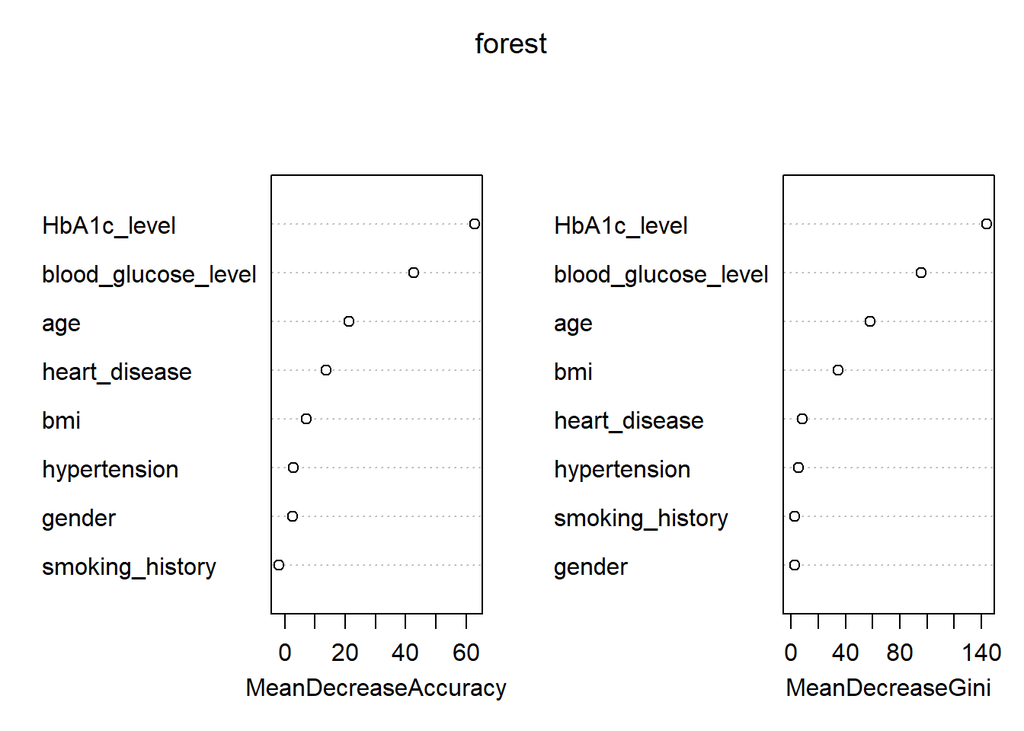

```r
varImpPlot(forest)
```

```r
log_reg_1 = multinom(diabetes ~ ., data = dpd_est)
log_reg_2 = multinom(diabetes ~ blood_glucose_level + HbA1c_level + age, data = dpd_est)
# estimation prediction
pred_log_reg_est_1 = predict(log_reg_1, dpd_est)
# validation prediction
pred_log_reg_val_1 = predict(log_reg_1, dpd_val)

# estimation prediction
pred_log_reg_est_2 = predict(log_reg_2, dpd_est)
# validation prediction
pred_log_reg_val_2 = predict(log_reg_2, dpd_val)
```

### misclass error

```r
# estimation
mis_log_reg_est_1 = calc_misclass(dpd_est$diabetes, pred_log_reg_est_1)
# validation
mis_log_reg_val_1 = calc_misclass(dpd_val$diabetes, pred_log_reg_val_1)

cat("misclassification error in Estimation is:", mis_log_reg_est_1,"and in Validation is:",mis_log_reg_val_1)
```

```
## misclassification error in Estimation is: 0.1142857 and in Validation is: 0.119171
```

```r
# estimation
mis_log_reg_est_2 = calc_misclass(dpd_est$diabetes, pred_log_reg_est_2)
# validation
mis_log_reg_val_2 = calc_misclass(dpd_val$diabetes, pred_log_reg_val_2)

cat("\nmisclassification error in Estimation is:", mis_log_reg_est_2,"and in Validation is:",mis_log_reg_val_2)
```

```
##
## misclassification error in Estimation is: 0.1337662 and in Validation is: 0.1761658
```

### Actual vs Predicted

#### log_reg_1

```r
table(predicted = pred_log_reg_val_1, actual = dpd_val$diabetes)
```

```
##          actual
## predicted  0  1
##         0 91 12
##         1 11 79
```

#### log_reg_2

```r
table(predicted = pred_log_reg_val_2, actual = dpd_val$diabetes)
```

```
##          actual
## predicted  0  1
##         0 87 19
##         1 15 72
```

```r
model_selection_df = rbind(model_selection_df,c("Model" = "Logestic Regression",
                            "EST_miscalss" = mis_log_reg_est_1,
                                "VAL_misclas" = mis_log_reg_val_1))

model_selection_df
```

```
##                 Model      EST_missclass      VAL_missclass
## 1            Best-KNN  0.112987012987013 0.0932642487046632
## 2                Tree 0.0636363636363636  0.119170984455959
## 3       Random forest 0.0246753246753247 0.0880829015544041
## 4 Logestic Regression  0.114285714285714  0.119170984455959
```

## LDA

```r
prior_vector = c(mean(dpd_est$diabetes == 0),mean(dpd_est$diabetes == 1))

lda_1 = lda(diabetes ~ ., data = dpd_est, prior = prior_vector)

# prediction
pred_lda_1_est = predict(lda_1, dpd_est)
pred_lda_1_val = predict(lda_1, dpd_val)
# misclass
mis_lda_1_est = calc_misclass(dpd_est$diabetes, pred_lda_1_est$class)
mis_lda_1_val = calc_misclass(dpd_val$diabetes, pred_lda_1_val$class)

cat("misclassification error in Estimation is:", mis_lda_1_est,"and in Validation is:",mis_lda_1_val)
```

```
## misclassification error in Estimation is: 0.1181818 and in Validation is: 0.1243523
```

```r
model_selection_df = rbind(model_selection_df,c("Model" = "LDA_1",
                            "EST_miscalss" = mis_lda_1_est,
                                "VAL_misclas" = mis_lda_1_val))

model_selection_df
```

```
##                 Model      EST_missclass      VAL_missclass
## 1            Best-KNN  0.112987012987013 0.0932642487046632
## 2                Tree 0.0636363636363636  0.119170984455959
## 3       Random forest 0.0246753246753247 0.0880829015544041
## 4 Logestic Regression  0.114285714285714  0.119170984455959
## 5               LDA_1  0.118181818181818  0.124352331606218
```

### Same probabilities in prior vector

```r
lda_2 = lda(diabetes ~ ., data = dpd_est, prior = c(0.5, 0.5))

# prediction
pred_lda_2_est = predict(lda_2, dpd_est)
pred_lda_2_val = predict(lda_2, dpd_val)
# misclass
mis_lda_2_est = calc_misclass(dpd_est$diabetes, pred_lda_2_est$class)
mis_lda_2_val = calc_misclass(dpd_val$diabetes, pred_lda_2_val$class)

cat("misclassification error in Estimation is:", mis_lda_2_est,"and in Validation is:",mis_lda_2_val)
```

```
## misclassification error in Estimation is: 0.1181818 and in Validation is: 0.119171
```

### Actual vs Predicted

#### lda_1

```r
table(predicted = pred_lda_1_val$class, actual = dpd_val$diabetes)
```

```
##          actual
## predicted  0  1
##         0 94 16
##         1  8 75
```

#### lda_2

```r
table(predicted = pred_lda_2_val$class, actual = dpd_val$diabetes)
```

```
##          actual
## predicted  0  1
##         0 93 14
##         1  9 77
```

```r
model_selection_df = rbind(model_selection_df,c("Model" = "LDA_2",
                            "EST_miscalss" = mis_lda_2_est,
                                "VAL_misclas" = mis_lda_2_val))

model_selection_df
```

```
##                 Model      EST_missclass      VAL_missclass
## 1            Best-KNN  0.112987012987013 0.0932642487046632
## 2                Tree 0.0636363636363636  0.119170984455959
## 3       Random forest 0.0246753246753247 0.0880829015544041
## 4 Logestic Regression  0.114285714285714  0.119170984455959
## 5               LDA_1  0.118181818181818  0.124352331606218
## 6               LDA_2  0.118181818181818  0.119170984455959
```

## QDA

```r
qda_1 = qda(diabetes ~ ., data = dpd_est, prior = prior_vector)

# prediction
pred_qda_1_est = predict(qda_1, dpd_est)
pred_qda_1_val = predict(qda_1, dpd_val)
# misclass
mis_qda_1_est = calc_misclass(dpd_est$diabetes, pred_qda_1_est$class)
mis_qda_1_val = calc_misclass(dpd_val$diabetes, pred_qda_1_val$class)

cat("misclassification error in Estimation is:", mis_qda_1_est,"and in Validation is:",mis_qda_1_val)
```

```
## misclassification error in Estimation is: 0.1324675 and in Validation is: 0.1502591
```

```r
model_selection_df = rbind(model_selection_df,c("Model" = "QDA_1",
                            "EST_miscalss" = mis_qda_1_est,
                                "VAL_misclas" = mis_qda_1_val))

model_selection_df
```

```
##                 Model      EST_missclass      VAL_missclass
## 1            Best-KNN  0.112987012987013 0.0932642487046632
## 2                Tree 0.0636363636363636  0.119170984455959
## 3       Random forest 0.0246753246753247 0.0880829015544041
## 4 Logestic Regression  0.114285714285714  0.119170984455959
## 5               LDA_1  0.118181818181818  0.124352331606218
## 6               LDA_2  0.118181818181818  0.119170984455959
## 7               QDA_1  0.132467532467532  0.150259067357513
```

```r
qda_2 = qda(diabetes ~ ., data = dpd_est, prior = c(0.5, 0.5))

# prediction
pred_qda_2_est = predict(qda_2, dpd_est)
pred_qda_2_val = predict(qda_2, dpd_val)
# misclass
mis_qda_2_est = calc_misclass(dpd_est$diabetes, pred_qda_2_est$class)
mis_qda_2_val = calc_misclass(dpd_val$diabetes, pred_qda_2_val$class)

cat("misclassification error in Estimation is:", mis_qda_2_est,"and in Validation is:",mis_qda_2_val)
```

```
## misclassification error in Estimation is: 0.1311688 and in Validation is: 0.1450777
```

```r
model_selection_df = rbind(model_selection_df,c("Model" = "QDA_2",
                            "EST_miscalss" = mis_qda_2_est,
                                "VAL_misclas" = mis_qda_2_val))

model_selection_df
```

```
##                 Model      EST_missclass      VAL_missclass
## 1            Best-KNN  0.112987012987013 0.0932642487046632
## 2                Tree 0.0636363636363636  0.119170984455959
## 3       Random forest 0.0246753246753247 0.0880829015544041
## 4 Logestic Regression  0.114285714285714  0.119170984455959
## 5               LDA_1  0.118181818181818  0.124352331606218
## 6               LDA_2  0.118181818181818  0.119170984455959
## 7               QDA_1  0.132467532467532  0.150259067357513
## 8               QDA_2  0.131168831168831  0.145077720207254
```

### Actual vs Predicted

#### qda_1

```r
table(predicted = pred_qda_1_val$class, actual = dpd_val$diabetes)
```

```
##          actual
## predicted  0  1
##         0 94 21
##         1  8 70
```

#### qda_2

```r
table(predicted = pred_qda_2_val$class, actual = dpd_val$diabetes)
```

```
##          actual
## predicted  0  1
##         0 94 20
##         1  8 71
```

## Naive Bayse

```r
navie_bayse = naiveBayes(diabetes ~ .,data = dpd_est, prior = prior_vector)

# prediction
pred_nba_est = predict(navie_bayse, dpd_est)
pred_nba_val = predict(navie_bayse, dpd_val)
# misclass
mis_nba_est = calc_misclass(dpd_est$diabetes, pred_nba_est)
mis_nba_val = calc_misclass(dpd_val$diabetes, pred_nba_val)

cat("misclassification error in Estimation is:", mis_nba_est,"and in Validation is:",mis_nba_val)
```

```
## misclassification error in Estimation is: 0.125974 and in Validation is: 0.134715
```

### Actual vs Predicted

```r
table(predicted = pred_nba_val, actual = dpd_val$diabetes)
```

```
##          actual
## predicted  0  1
##         0 96 20
##         1  6 71
```

```r
model_selection_df = rbind(model_selection_df,c("Model" = "Navie_Bayse",
                            "EST_miscalss" = mis_nba_est,
                                "VAL_misclas" = mis_nba_val))

model_selection_df
```

```
##                 Model      EST_missclass      VAL_missclass
## 1            Best-KNN  0.112987012987013 0.0932642487046632
## 2                Tree 0.0636363636363636  0.119170984455959
## 3       Random forest 0.0246753246753247 0.0880829015544041
## 4 Logestic Regression  0.114285714285714  0.119170984455959
## 5               LDA_1  0.118181818181818  0.124352331606218
## 6               LDA_2  0.118181818181818  0.119170984455959
## 7               QDA_1  0.132467532467532  0.150259067357513
## 8               QDA_2  0.131168831168831  0.145077720207254
## 9         Navie_Bayse  0.125974025974026  0.134715025906736
```

Best model is random forest but we use it to show its accuracy. now for better accuracy we use k-fold cross validation for this models.

## K-fold cross validation

K-fold cross-validation is a technique commonly used in machine learning and statistical modeling to assess the performance and generalization ability of a predictive model. It involves partitioning a dataset into K subsets or “folds” of approximately equal size.

The K-fold cross-validation process can be summarized as follows: 1.The dataset is divided into K equal-sized subsets or folds. 2.The model is trained K times, each time using K-1 folds as the training data and the remaining fold as the validation or test data. 3.For each training iteration, the model is trained on the training data and then evaluated on the validation data. 4.The performance of the model is recorded for each iteration, typically using a predefined evaluation metric such as accuracy, precision, recall, or mean squared error. 5.The performance results from the K iterations are averaged to obtain a single performance metric, which represents the overall performance of the model. 6.Optionally, after selecting the best-performing model, it can be retrained on the entire dataset for final evaluation on a separate, unseen test set.

The main advantage of K-fold cross-validation is that it allows for a more reliable estimate of model performance compared to a single train-test split. It helps to mitigate the impact of dataset variability and provides a more robust evaluation of the model’s ability to generalize to new, unseen data. Moreover, K-fold cross-validation aids in assessing the model’s stability and identifying potential issues such as overfitting or underfitting.

```r
dim(dpd_trn)
```

```
## [1] 963   9
```

there is 963 records.

```r
k_fold = 10

set.seed(100)
random_vector = c(rep(1, 97), rep(2, 97), rep(3, 97),rep(4, 96), rep(5, 96), rep(6, 96),rep(7,96), rep(8,96), rep(9,96), rep(10, 96))

random_vector = sample(random_vector)

kfold_trn = dpd_trn
kfold_trn$folds = random_vector

head(kfold_trn)
```

```
## # A tibble: 6 × 10
##   gender   age hypertension heart_…¹ smoki…²   bmi HbA1c…³ blood…⁴ diabe…⁵ folds
##   <fct>  <dbl> <fct>        <fct>    <fct>   <dbl>   <dbl>   <dbl> <fct>   <dbl>
## 1 Female    37 0            0        yes      24.7     6       158 0           8
## 2 Male      63 1            0        yes      25.2     8.2     155 1           6
## 3 Female    80 0            0        never    25.0     9       145 1           4
## 4 Female    54 0            0        never    31.9     9       159 1           7
## 5 Female    72 0            0        yes      27.3     3.5     160 0           8
## 6 Female    80 1            0        yes      31.1     6.1     260 1          10
## # … with abbreviated variable names ¹heart_disease, ²smoking_history,
## #   ³HbA1c_level, ⁴blood_glucose_level, ⁵diabetes
```

```r
misclass_df = data.frame(matrix(NA, nrow = 14, ncol = 11))
colnames(misclass_df) = c("model","k=1","k=2","k=3","k=4","k=5","k=6","k=7","k=8","k=9","k=10")
misclass_df
```

```
##    model k=1 k=2 k=3 k=4 k=5 k=6 k=7 k=8 k=9 k=10
## 1     NA  NA  NA  NA  NA  NA  NA  NA  NA  NA   NA
## 2     NA  NA  NA  NA  NA  NA  NA  NA  NA  NA   NA
## 3     NA  NA  NA  NA  NA  NA  NA  NA  NA  NA   NA
## 4     NA  NA  NA  NA  NA  NA  NA  NA  NA  NA   NA
## 5     NA  NA  NA  NA  NA  NA  NA  NA  NA  NA   NA
## 6     NA  NA  NA  NA  NA  NA  NA  NA  NA  NA   NA
## 7     NA  NA  NA  NA  NA  NA  NA  NA  NA  NA   NA
## 8     NA  NA  NA  NA  NA  NA  NA  NA  NA  NA   NA
## 9     NA  NA  NA  NA  NA  NA  NA  NA  NA  NA   NA
## 10    NA  NA  NA  NA  NA  NA  NA  NA  NA  NA   NA
## 11    NA  NA  NA  NA  NA  NA  NA  NA  NA  NA   NA
## 12    NA  NA  NA  NA  NA  NA  NA  NA  NA  NA   NA
## 13    NA  NA  NA  NA  NA  NA  NA  NA  NA  NA   NA
## 14    NA  NA  NA  NA  NA  NA  NA  NA  NA  NA   NA
```

```r
for(i in 1:k_fold){
    estimation = kfold_trn[kfold_trn$folds != i,]
    validation = kfold_trn[kfold_trn$folds == i,]
    prior_vector = c(mean(estimation$diabetes == 0),mean(estimation$diabetes == 1))
    # logestic_1
    fold_log_1 = multinom(diabetes ~ . - folds, data = estimation)
    log_pred_1 = predict(fold_log_1, validation)
    log_mis_1 = calc_misclass(validation$diabetes, log_pred_1)
    misclass_df[1,(i+1)] = log_mis_1
    # logestic_2
    fold_log_2 = multinom(diabetes ~ blood_glucose_level + HbA1c_level + age, data = estimation)
    log_pred_2 = predict(fold_log_2, validation)
    log_mis_2 = calc_misclass(validation$diabetes, log_pred_2)
    misclass_df[2,(i+1)] = log_mis_2
    # lda_1
    fold_lda_1 = lda(diabetes ~ . - folds, data = estimation, prior = prior_vector)
    lda_pred_1 = predict(fold_lda_1, validation)
    lda_mis_1 = calc_misclass(validation$diabetes, lda_pred_1$class)
    misclass_df[3,(i+1)] = lda_mis_1
    # lda_2
    fold_lda_2 = lda(diabetes ~ . - folds, data = estimation, prior = c(0.5,0.5))
    lda_pred_2 = predict(fold_lda_2, validation)
    lda_mis_2 = calc_misclass(validation$diabetes, lda_pred_2$class)
    misclass_df[4,(i+1)] = lda_mis_2
    # qda_1
    fold_qda_1 = qda(diabetes ~ . - folds, data = estimation, prior = prior_vector)
    qda_pred_1 = predict(fold_qda_1, validation)
    qda_mis_1 = calc_misclass(validation$diabetes, qda_pred_1$class)
    misclass_df[5,(i+1)] = qda_mis_1
    # qda_2
    fold_qda_2 = qda(diabetes ~ . - folds, data = estimation, prior = c(0.5,0.5))
    qda_pred_2 = predict(fold_qda_2, validation)
    qda_mis_2 = calc_misclass(validation$diabetes, qda_pred_2$class)
    misclass_df[6,(i+1)] = qda_mis_2
    # Naive Bayse
    fold_nba = naiveBayes(diabetes ~ . - folds,data = estimation, prior = prior_vector)
    nba_pred = predict(fold_nba, validation)
    nba_mis = calc_misclass(validation$diabetes, nba_pred)
    misclass_df[7,(i+1)] = nba_mis
    # Tree
    fold_tree = rpart(diabetes ~ . - folds, data = estimation, cp = best_cp, minsplit = best_minsplit)
    tree_pred = predict(fold_tree, validation, type = "class")
    tree_mis = calc_misclass(validation$diabetes, tree_pred)
    misclass_df[8,(i+1)] = tree_mis
    }
for(i in 1:k_fold){
  estimation = kfold_trn[kfold_trn$folds != i,]
  validation = kfold_trn[kfold_trn$folds == i,]
  est_scl = estimation

  est_scl$age = scale(est_scl$age)
  age.center = attr(est_scl$age,"scaled:center")
  age.scale = attr(est_scl$age,"scaled:scale")

  est_scl$bmi = scale(est_scl$bmi)
  bmi.center = attr(est_scl$bmi,"scaled:center")
  bmi.scale = attr(est_scl$bmi,"scaled:scale")

  est_scl$HbA1c_level = scale(est_scl$HbA1c_level)
  HbA1c_level.center = attr(est_scl$HbA1c_level,"scaled:center")
  HbA1c_level.scale = attr(est_scl$HbA1c_level,"scaled:scale")

  est_scl$blood_glucose_level = scale(est_scl$blood_glucose_level)
  blood_glucose_level.center = attr(est_scl$blood_glucose_level,"scaled:center")
  blood_glucose_level.scale = attr(est_scl$blood_glucose_level,"scaled:scale")

  val_scl = validation

  val_scl$age = scale(val_scl$age, center = age.center, scale = age.scale)
  val_scl$bmi = scale(val_scl$bmi, center = bmi.center, scale = bmi.scale)
  val_scl$HbA1c_level = scale(val_scl$HbA1c_level, center = HbA1c_level.center, scale = HbA1c_level.scale)
  val_scl$blood_glucose_level = scale(val_scl$blood_glucose_level, center = blood_glucose_level.center,scale = blood_glucose_level.scale)

  knn_list = list(
    k_9 = knn3(diabetes ~ . - folds, data = est_scl, k = 9),
    k_10 = knn3(diabetes ~ . - folds, data = est_scl, k = 10),
    k_11 = knn3(diabetes ~ . - folds, data = est_scl, k = 11),
    k_12 = knn3(diabetes ~ . - folds, data = est_scl, k = 12),
    k_13 = knn3(diabetes ~ . - folds, data = est_scl, k = 13),
    k_14 = knn3(diabetes ~ . - folds, data = est_scl, k = 14)
  )
  knn_pred = lapply(knn_list, predict, val_scl, type = "class")
  knn_mis = sapply(knn_pred, calc_misclass, val_scl$diabetes)
  misclass_df[9,(i+1)] = knn_mis[1]
  misclass_df[10,(i+1)] = knn_mis[2]
  misclass_df[11,(i+1)] = knn_mis[3]
  misclass_df[12,(i+1)] = knn_mis[4]
  misclass_df[13,(i+1)] = knn_mis[5]
  misclass_df[14,(i+1)] = knn_mis[6]
}
```

```r
misclass_df[,1] = c("log_reg_1","log_reg_2","lda_1","lda_2","qda_1","qda_2","Naive Bayse","tree","knn(k=9)","knn(k=10)","knn(k=11)","knn(k=12)","knn(k=13)","knn(k=14)")
misclass_df$mean = rowMeans(misclass_df[,-1])
misclass_df
```

```
##          model        k=1       k=2        k=3        k=4       k=5       k=6
## 1    log_reg_1 0.14432990 0.1546392 0.11340206 0.05208333 0.1250000 0.1875000
## 2    log_reg_2 0.17525773 0.1649485 0.13402062 0.10416667 0.1250000 0.2187500
## 3        lda_1 0.14432990 0.1443299 0.10309278 0.06250000 0.1145833 0.1875000
## 4        lda_2 0.12371134 0.1443299 0.10309278 0.06250000 0.1041667 0.1979167
## 5        qda_1 0.12371134 0.1443299 0.09278351 0.12500000 0.1145833 0.2083333
## 6        qda_2 0.12371134 0.1443299 0.10309278 0.12500000 0.1145833 0.1979167
## 7  Naive Bayse 0.13402062 0.1340206 0.11340206 0.10416667 0.1250000 0.1875000
## 8         tree 0.09278351 0.1030928 0.08247423 0.08333333 0.1041667 0.1875000
## 9     knn(k=9) 0.15463918 0.1340206 0.10309278 0.07291667 0.1250000 0.1875000
## 10   knn(k=10) 0.16494845 0.1237113 0.10309278 0.06250000 0.1250000 0.1875000
## 11   knn(k=11) 0.16494845 0.1443299 0.08247423 0.07291667 0.1145833 0.1562500
## 12   knn(k=12) 0.17525773 0.1443299 0.07216495 0.07291667 0.1145833 0.1458333
## 13   knn(k=13) 0.16494845 0.1546392 0.07216495 0.07291667 0.1250000 0.1875000
## 14   knn(k=14) 0.14432990 0.1443299 0.07216495 0.06250000 0.1145833 0.1875000
##          k=7        k=8       k=9       k=10      mean
## 1  0.1145833 0.08333333 0.1458333 0.11458333 0.1235288
## 2  0.1041667 0.11458333 0.1562500 0.14583333 0.1442977
## 3  0.1354167 0.10416667 0.1354167 0.14583333 0.1277169
## 4  0.1250000 0.10416667 0.1458333 0.13541667 0.1246134
## 5  0.1354167 0.17708333 0.1458333 0.12500000 0.1392075
## 6  0.1354167 0.16666667 0.1458333 0.12500000 0.1381551
## 7  0.1458333 0.10416667 0.1562500 0.09375000 0.1298110
## 8  0.0937500 0.13541667 0.1354167 0.08333333 0.1101267
## 9  0.1458333 0.14583333 0.1145833 0.11458333 0.1298003
## 10 0.1458333 0.13541667 0.1354167 0.12500000 0.1308419
## 11 0.1458333 0.13541667 0.1458333 0.12500000 0.1287586
## 12 0.1666667 0.14583333 0.1562500 0.13541667 0.1329253
## 13 0.1666667 0.11458333 0.1562500 0.13541667 0.1350086
## 14 0.1666667 0.14583333 0.1562500 0.12500000 0.1319158
```

# Best model

best model is tree model based on 10-fold cross validation.

```r
final_mod = rpart(diabetes ~ ., data = dpd_trn, cp = best_cp, minsplit = best_minsplit)

# Prediction
final_trn_pred = predict(final_mod, dpd_trn, type = "class")
final_tst_pred = predict(final_mod, dpd_tst, type = "class")
# missclassification
final_trn_mis = calc_misclass(dpd_trn$diabetes, final_trn_pred)
final_tst_mis = calc_misclass(dpd_tst$diabetes, final_tst_pred)
cat("misclassification error in train data set is:", final_trn_mis,
    "\nmisclassification error in test data set is:", final_tst_mis)
```

```
## misclassification error in train data set is: 0.06022845
## misclassification error in test data set is: 0.153527
```

## Actual vs Predicted

```r
table(predicted = final_tst_pred, actual = dpd_tst$diabetes)
```

```
##          actual
## predicted   0   1
##         0 100  17
##         1  20 104
```

we have more misclass in healthy people. as we see, we have 17% missclassification in healthy people that we have diagnosed diabetes. but in people with diabetes, we have misdiagnosed 17 people which contains 14% of people with diabetes.